# Replication Analysis

David John Baker

24/06/2020

This document provides the analysis for “Lyrics’ Emotional Influences in Songs: A Conceptual Replication of Ali and Peynircioğlu’s (2006) Study”. The script creates both figures for the paper as well as the statistical analysis.

- [ ] Add in Analyses about Inconsistencies in 2,3,4
- [ ] Re-order factor Levels in both data

```r
# Libraries Needed
library(ggridges)
library(ez)
library(multcomp)
library(lme4)
```

```r
library(sjPlot)
library(patchwork)
library(stringr)
library(dplyr)
library(magrittr)
library(readr)
library(ggplot2)
library(tidyr)
library(gt)

# Paper Data

table_1_values <- c(7.85, 8.18, 6.62, 6.91,
                    5.79, 5.20, 6.51, 6.11,
                    7.75, 7.95, 4.05, 5.41,
                    5.00, 4.41, 6.08, 6.59)

grim_test <- function(sample_size, likert_start, likert_end, means){
  integer_values <- sample_size * means
  bottom <- round(floor(integer_values)/ sample_size, 2)
  top <- round(ceiling(integer_values)/ sample_size, 2)
  df <- data.frame(bottom, top, means)
  df$sample_size <- sample_size
  df$possible <- ifelse(df$bottom == means | df$top == means, yes = TRUE,no = FALSE)
  df
}

table_1 <- grim_test(32, 1, 9, table_1_values)


table_1$gender <- rep(c("woman","man"),8)
table_1$lyrics <- rep(c("no lyric", "no lyric", "lyric","lyric"),4)
table_1$emotions <- c(rep("happy",4), rep("sad",4), rep("calm",4), rep("angry",4))

table_1 <- table_1 %>%
  tibble() %>%
    mutate(valence = case_when(
    emotions == "happy" ~ "positive",
    emotions == "calm" ~ "positive",
    emotions == "angry" ~ "negative",
    emotions == "sad" ~ "negative"
  ))


# LSU Data
df_complete <- read_csv("Complete_Data.csv", col_types = cols(age = col_character()))

df_complete <- df_complete %>%
  mutate(age = str_replace_all(string = age, pattern = "eighteen", replacement = "18")) %>%
  mutate(age = str_replace_all(string = age, pattern = "3", replacement = NA_character_)) %>%
  mutate(age = as.numeric(age))

valence_table_exact <- read_csv("data/valence_sheet.csv")
df_complete %>%
  left_join(valence_table_exact) %>%
  rename(track_valence = Valence) -> df_complete
df_complete <- df_complete %>%
   mutate(global_valence = case_when(
    track_valence == "Happy" ~ "positive",
    track_valence == "Calm" ~ "positive",
    track_valence == "Angry" ~ "negative",
    track_valence == "Sad" ~ "negative"
  ))

gender_table <- df_complete %>%
  select(subject, gender) %>%
  distinct() %>%
  mutate(gender = str_to_lower(gender)) %>%
  mutate(cleaned_gender = case_when(
    gender == "cis male" ~ "male",
    gender == "false" ~ NA_character_,
    gender == "female" ~ "female",
    gender == "femalen" ~ "female",
    gender == "male" ~ "male",
    gender == "malen" ~ "male"
  )) %>%
  select(subject,cleaned_gender)
```

Before running analysis on our own data, below we visualize the results that were reported in the original paper so we know if we match them.

## AP Data

In the A+P 2006 paper, under Experiment 1, the authors report results of4 x 2 x 2 ANOVA with Lyrics, Emotion, and Gender:

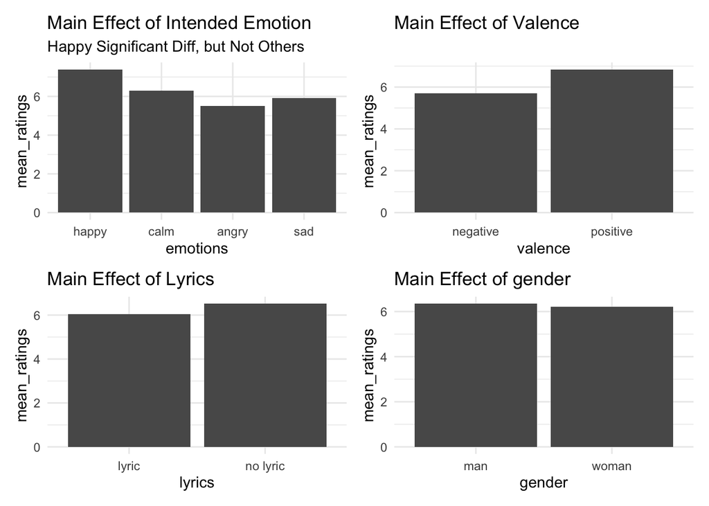

```r
table_1$emotions <- factor(table_1$emotions, levels = c("happy","calm","angry","sad"))

# Main Effect of Intended Emotion
table_1 %>%
  group_by(emotions) %>%
  summarise(mean_ratings = mean(means))  %>%
  ggplot(aes(y = mean_ratings,
             x = emotions)) +
  geom_bar(stat = "identity") +
  labs(title = "Main Effect of Intended Emotion",
       subtitle = "Happy Significant Diff, but Not Others") +
  theme_minimal() -> me_intended_emotion
# Main Effect of Valence
table_1 %>%
  group_by(valence) %>%
  summarise(mean_ratings = mean(means))  %>%
  ggplot(aes(y = mean_ratings,
             x = valence)) +
  geom_bar(stat = "identity") +
  labs(title = "Main Effect of Valence") +
  theme_minimal() -> me_valence
# Main Effect of Lyrics
table_1 %>%
  group_by(lyrics) %>%
  summarise(mean_ratings = mean(means))  %>%
  ggplot(aes(y = mean_ratings,
             x = lyrics)) +
  geom_bar(stat = "identity") +
  labs(title = "Main Effect of Lyrics") +
  theme_minimal() -> me_lyrics
# NO Main Effect of Gender

table_1 %>%
  group_by(gender) %>%
  summarise(mean_ratings = mean(means))  %>%
  ggplot(aes(y = mean_ratings,
             x = gender)) +
  geom_bar(stat = "identity") +
  labs(title = "Main Effect of gender") +
  theme_minimal() -> me_gender
(ap_panel <- ( me_intended_emotion | me_valence ) / ( me_lyrics | me_gender ))
```

## LSU Data

First Visualise:

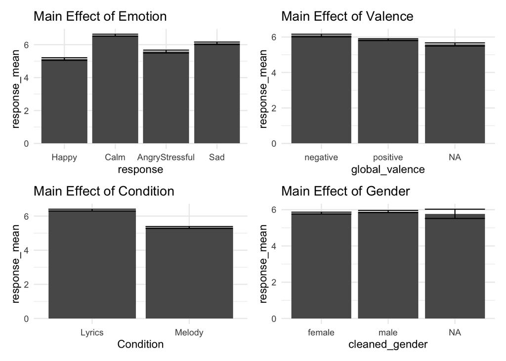

```r
# Standard Deviation of Mean Function
std <- function(x) sd(x)/sqrt(length(x))

# Create Long Data, Subset Only Congruancy Conditions
df_congruent <- df_complete %>%
  select(subject, Happy:AngryStressful, Condition, track_valence, global_valence) %>%
  pivot_longer(cols = Happy:AngryStressful, names_to = "response",values_to = "rating") %>%
  # Congrency Add Here!!
  mutate(congru = track_valence == response) %>%
  filter(congru == TRUE)

df_congruent$response <- factor(df_congruent$response, levels = c("Happy","Calm","AngryStressful","Sad"))

# Main Effect of Intended Emotion
me_intended_emotion_lsu <- df_congruent %>%
  group_by(response) %>%
  summarise(
    response_mean = mean(rating),
    response_sd = sd(rating),
    response_std = std(rating)
  ) %>%
  ggplot(aes(x = response, y = response_mean)) +
  geom_bar(stat = "identity") +
  theme_minimal() +
    geom_errorbar(aes(ymin = response_mean + response_std,
                      ymax = response_mean - response_std)) +
  labs(title = "Main Effect of Emotion")
# Main Effect of Valence
me_valence_lsu <- df_congruent %>%
  group_by(global_valence) %>%
  summarise(
    response_mean = mean(rating),
    response_sd = sd(rating),
    response_std = std(rating)
  ) %>%
  ggplot(aes(x = global_valence, y = response_mean)) +
  geom_bar(stat = "identity") +
  geom_errorbar(aes(ymin = response_mean + response_std,
                   ymax = response_mean - response_std)) +
  theme_minimal() +
  labs(title = "Main Effect of Valence")
# Main Effect of Lyrics
me_lyrics_lsu <- df_congruent %>%
  group_by(Condition) %>%
  summarise(
    response_mean = mean(rating),
    response_sd = sd(rating),
    response_std = std(rating)
  ) %>%
  ggplot(aes(x = Condition, y = response_mean)) +
  geom_bar(stat = "identity") +
  theme_minimal() +
  geom_errorbar(aes(ymin = response_mean + response_std,
                    ymax = response_mean - response_std)) +
  labs(title = "Main Effect of Condition")
# Main Effect of Gender
me_gender_lsu <- df_congruent %>%
  left_join(gender_table) %>%
  group_by(cleaned_gender) %>%
  summarise(
    response_mean = mean(rating),
    response_sd = sd(rating),
    response_std = std(rating)
  ) %>%
  ggplot(aes(x = cleaned_gender, y = response_mean)) +
  geom_bar(stat = "identity") +
  theme_minimal() +
  geom_errorbar(aes(ymin = response_mean + response_std,
                    ymax = response_mean - response_std)) +
  labs(title = "Main Effect of Gender")
(lsu_panel <- (me_intended_emotion_lsu | me_valence_lsu) / (me_lyrics_lsu | me_gender_lsu))
```

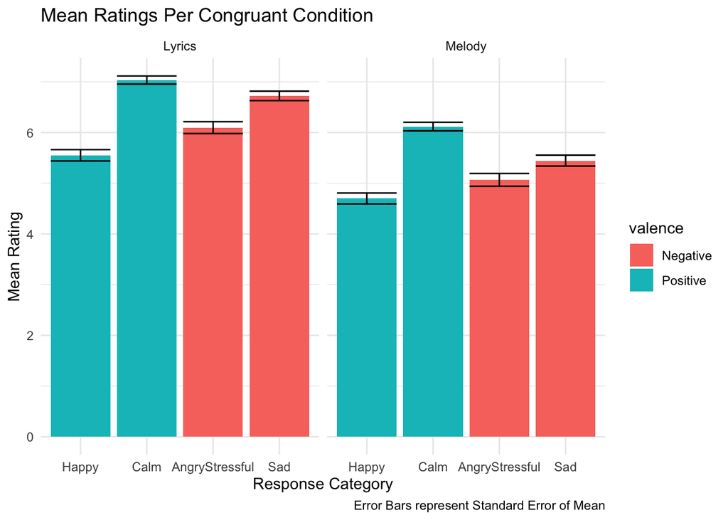

```r
# Big Plots of LSU
# Make Mean Rating Per Condition
df_congruent  %>%
  left_join(gender_table) %>%
  group_by(Condition, response) %>%
  summarise(mean_rating = mean(rating),
            sd_rating = sd(rating),
            max_rating = max(rating),
            min_rating = min(rating),
            se_rating = std(rating),
            number_of_ratings = n()) %>%
  mutate(response = factor(response, levels = c("Happy","Calm","AngryStressful","Sad"))) %>%
  mutate(valence = case_when(
    response == "AngryStressful" ~ "Negative",
    response == "Sad" ~ "Negative",
    response == "Happy" ~ "Positive",
    response == "Calm" ~ "Positive"

  )) %>%
  ggplot(aes(x = response, y = mean_rating, fill = valence)) +
  geom_bar(stat = "identity") +
  facet_wrap(~Condition) +
  geom_errorbar(aes(ymin = mean_rating + se_rating, ymax = mean_rating - se_rating)) +
  labs(title = "Mean Ratings Per Congruant Condition",
       caption = "Error Bars represent Standard Error of Mean",
       x = "Response Category",
       y = "Mean Rating") +
  theme_minimal()
```

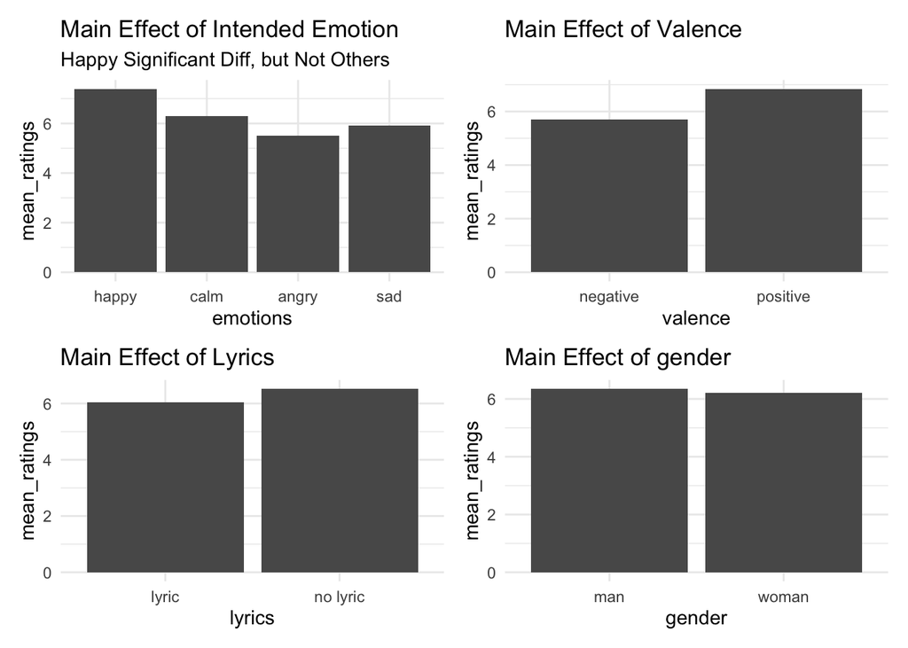

```r
# Big Plots of AP (Data Problem)

ap_panel
```

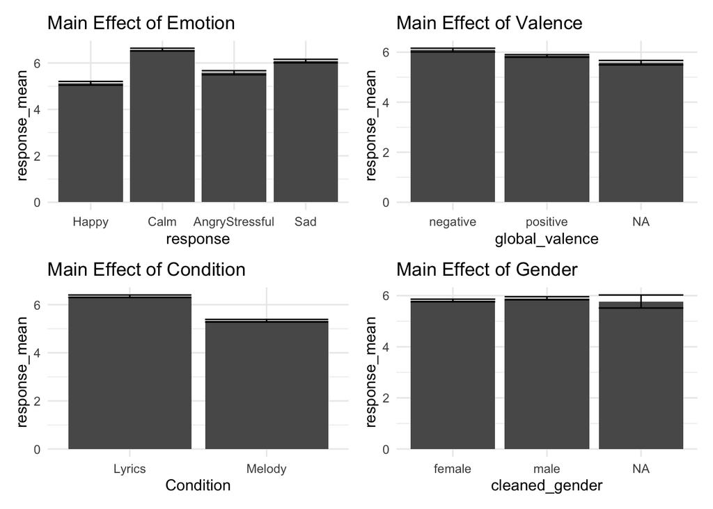

```r
lsu_panel
```

Also wanted to see if congruancy always higher as they report but no numbers or graphs:

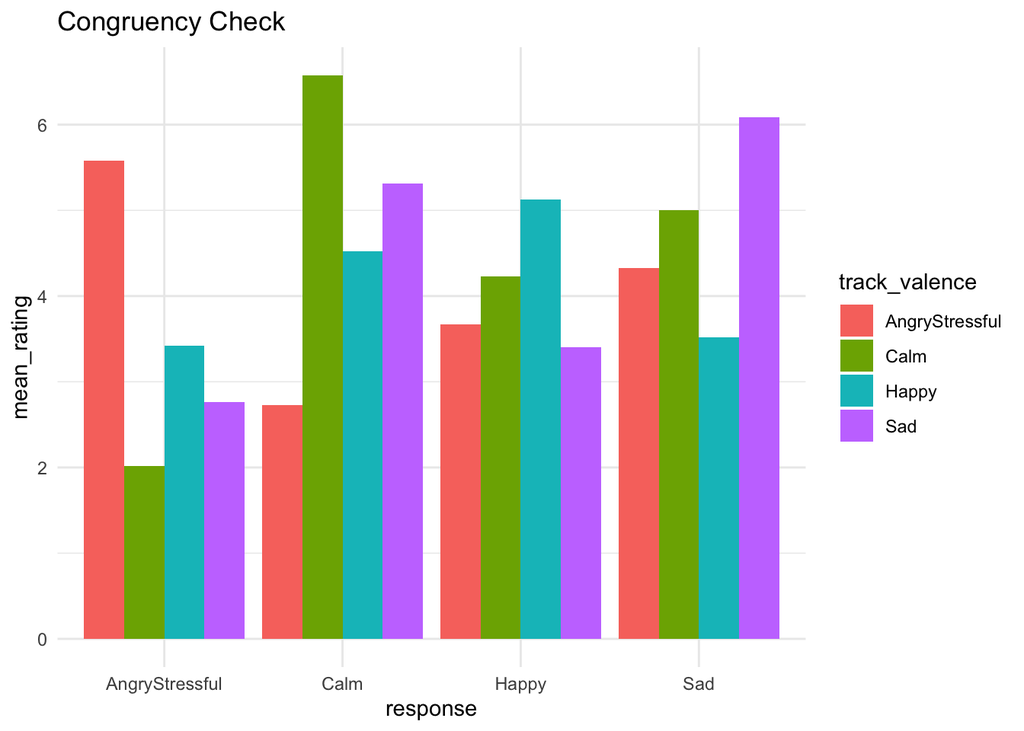

```r
df_complete %>%
  select(subject, Happy:AngryStressful, Condition, track_valence, global_valence) %>%
  pivot_longer(cols = Happy:AngryStressful, names_to = "response",values_to = "rating") %>%
  group_by(track_valence, response) %>%
  summarise(
    mean_rating = mean(rating)
  ) %>%
  ggplot(aes(x = response, fill = track_valence, y = mean_rating)) +
  geom_bar(stat = "identity", position = "dodge") +
  theme_minimal() +
  labs(title = "Congruency Check")
```

## Statistical Analysis

- First Re-Report the 4 x 2 x 2 ANOVA (Not with Gender)

```r
options(scipen = 999)
df_replicate_anova <- df_congruent

factorial_anova_direct_replication <- ezANOVA(
  data = df_replicate_anova
  , dv = .(rating)
  , wid = .(subject)
  , within = .(Condition, response),
  type = 3, # Do you want to do Type III sum of Squares, doesnt change results...
  detailed = TRUE,
  return_aov = TRUE
)
# Check Exlusion Criteria from Pre-Registration since this is on border
print(factorial_anova_direct_replication)
```

```
## $ANOVA
##               Effect DFn DFd          SSn      SSd           F
## 1        (Intercept)   1 128 35543.790940 847.8497 5366.051696
## 2          Condition   1 128   268.096899 124.1687  276.369133
## 3           response   3 384   261.893653 998.9657   33.557095
## 4 Condition:response   3 384     5.250484 262.3589    2.561613
##                                                                                                                    p
## 1 0.0000000000000000000000000000000000000000000000000000000000000000000000000000000000000000000000000000000002295243
## 2 0.0000000000000000000000000000000009041560394764533048728672327013248744772561004464030962488777516751024623160167
## 3 0.0000000000000000002777326551014278800132935452982074364358195554580076248527009674660348537145182490348815917969
## 4 0.0545824389638071144625897090918442700058221817016601562500000000000000000000000000000000000000000000000000000000
##   p<.05         ges
## 1     * 0.940881089
## 2     * 0.107177029
## 3     * 0.104957440
## 4       0.002345439
##
## $`Mauchly's Test for Sphericity`
##               Effect         W           p p<.05
## 3           response 0.8553007 0.001358939     *
## 4 Condition:response 0.9462910 0.220972709
##
## $`Sphericity Corrections`
##               Effect       GGe                     p[GG] p[GG]<.05       HFe
## 3           response 0.8972105 0.00000000000000001486788         * 0.9183225
## 4 Condition:response 0.9622888 0.05692676116719201651062           0.9868555
##                        p[HF] p[HF]<.05
## 3 0.000000000000000006562326         *
## 4 0.055388119059531989996081
##
## $aov
##
## Call:
## aov(formula = formula(aov_formula), data = data)
##
## Grand Mean: 5.868702
##
## Stratum 1: subject
##
## Terms:
```

[output cut: 22 more lines]

```
## Deg. of Freedom        3       384
##
## Residual standard error: 1.612908
## 3 out of 6 effects not estimable
## Estimated effects may be unbalanced
##
## Stratum 4: subject:Condition:response
##
## Terms:
##                 Condition:response Residuals
## Sum of Squares             5.25048 262.35889
## Deg. of Freedom                  3       384
##
## Residual standard error: 0.826575
## Estimated effects may be unbalanced
```

- Main Effect of Condition (Lyrics) and Response (Emotion)
- No significant interaction with all data
- (it does emerge with missing gender people in there)

## Data Caveat

When making the top charts before running our data, I was kind of shocked at how low their sample size was. While that is not too much of a problem in general, I had just read [this article](https://medium.com/@jamesheathers/the-grim-test-further-points-follow-ups-and-future-directions-afd55ff67bb0) and for fun wanted to see what would happen if I put their data into this calculator. Their [preprint is here](https://peerj.com/preprints/2064/).

The long story short is that only seven out of their sixteen values were actually mathematically possible given their sample size. This could just be sloppieness on their part. But I looked into it a bit more and plotted which means were possible and which were not. What I found a bit peculiar, is the first main effect that they report of condition, with happy being higher than the other ones (but no difference between the two), the two values here that are the highest in the happy condition (women, happy, no lyric + man happy no lyric) are both impossible values. I didn’t want to get into more speculation, but this probably should be addressed in the Discussion section.

```r
table_1 %>%
  mutate(number_of_possible = sum(possible)) %>%
  mutate(total_values = length(possible)) %>%
  mutate(percent_possible = number_of_possible/total_values) %>%
  select(-valence, -number_of_possible, -total_values) %>%
  gt()
```

| bottom | top | means | sample_size | possible | gender | lyrics | emotions | percent_possible |
| --- | --- | --- | --- | --- | --- | --- | --- | --- |
| 7.84 | 7.88 | 7.85 | 32 | FALSE | woman | no lyric | happy | 0.4375 |
| 8.16 | 8.19 | 8.18 | 32 | FALSE | man | no lyric | happy | 0.4375 |
| 6.59 | 6.62 | 6.62 | 32 | TRUE | woman | lyric | happy | 0.4375 |
| 6.91 | 6.94 | 6.91 | 32 | TRUE | man | lyric | happy | 0.4375 |
| 5.78 | 5.81 | 5.79 | 32 | FALSE | woman | no lyric | sad | 0.4375 |
| 5.19 | 5.22 | 5.20 | 32 | FALSE | man | no lyric | sad | 0.4375 |
| 6.50 | 6.53 | 6.51 | 32 | FALSE | woman | lyric | sad | 0.4375 |
| 6.09 | 6.12 | 6.11 | 32 | FALSE | man | lyric | sad | 0.4375 |
| 7.75 | 7.75 | 7.75 | 32 | TRUE | woman | no lyric | calm | 0.4375 |
| 7.94 | 7.97 | 7.95 | 32 | FALSE | man | no lyric | calm | 0.4375 |
| 4.03 | 4.06 | 4.05 | 32 | FALSE | woman | lyric | calm | 0.4375 |
| 5.41 | 5.44 | 5.41 | 32 | TRUE | man | lyric | calm | 0.4375 |
| 5.00 | 5.00 | 5.00 | 32 | TRUE | woman | no lyric | angry | 0.4375 |
| 4.41 | 4.44 | 4.41 | 32 | TRUE | man | no lyric | angry | 0.4375 |
| 6.06 | 6.09 | 6.08 | 32 | FALSE | woman | lyric | angry | 0.4375 |
| 6.56 | 6.59 | 6.59 | 32 | TRUE | man | lyric | angry | 0.4375 |

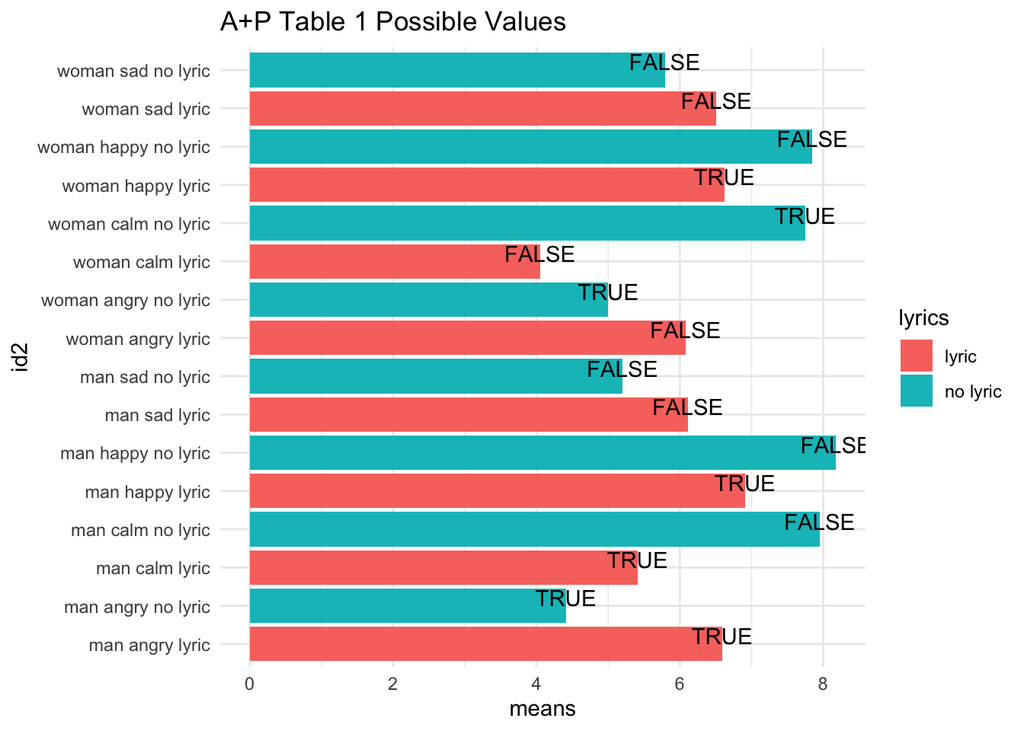

```r
(possible_bar_chart <- table_1 %>%
  tibble() %>%
  mutate(id = row_number()) %>%
  mutate(id2 = paste(gender, emotions, lyrics)) %>%
  ggplot(aes(y = means,
             x = id2,
             fill  = lyrics)) +
  geom_bar(stat = "identity") +
  stat_summary(fun = sum, geom="text", aes(label=possible), vjust = 0) +
  theme_minimal() +
  coord_flip() +
  labs(title = "A+P Table 1 Possible Values") )
```

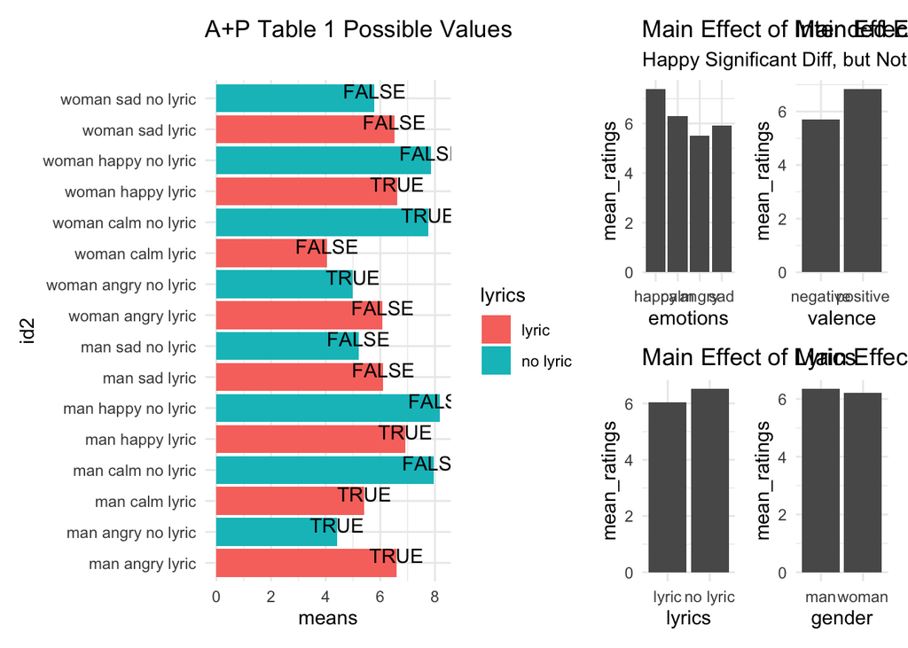

```r
possible_bar_chart + ap_panel
```

## Extending

I think we should write the paper and say that since they didn’t find an effect of gender, it was not worth testing. They had some weird literature suggesting why it should be added, but in order to figure out if the results here are generlizable (obvs not since we didn’t see any other patterns consistent with their original findings) we have other ideas that we might put forward.

Instead of thinking that there would be a main effect of gender, we might think that people with musical training will respond with more variability than those without.

To explore this we do the following

- Correlate GMSIs with mean rating in congruancy conditions
- Then add GMSI in linear model as interaction

> rating ~ emotions + lyrics:gmsi

Or somethingl like that.